# Assignment_week1

Eszter Takacs

April 2016

## Loading the data

- Loading and preprocessing the data

```r
setwd("~/Eszter C/Spotfire Edu/Data science")
unzip("repdata-data-activity.zip")
mydata <- read.csv("activity.csv")
```

## What is mean total number of steps taken per day?

- Make a histogram of the total number of steps taken each day

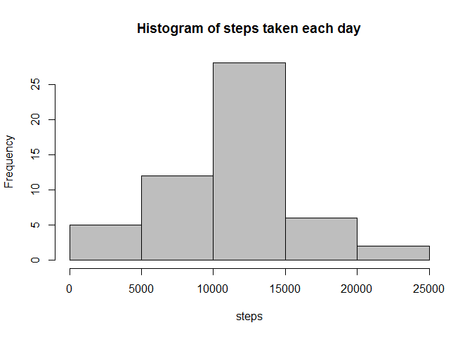

```r
totalsteps <- aggregate(steps ~ date, data=mydata, FUN=sum)
hist(totalsteps$steps, xlab="steps", main="Histogram of steps taken each day", col="grey")

library(ggplot2)
```

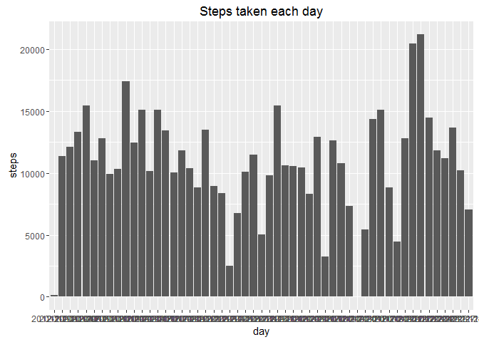

```r
qplot(date, data=totalsteps, geom="bar", weight=steps, ylab="steps", xlab="day", main="Steps taken each day")
```

- Calculate and report the mean and median total number of steps taken per day

```r
mean(totalsteps$steps)
```

```
## [1] 10766.19
```

```r
median(totalsteps$steps)
```

```
## [1] 10765
```

## What is the average daily activity pattern?

- Make a time series plot (i.e. type = “l”) of the 5-minute interval (x-axis) and the average number of steps taken, averaged across all days (y-axis)

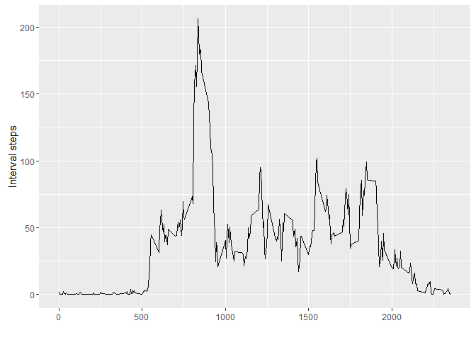

```r
intervalsteps <- aggregate(steps ~ interval, data=mydata, FUN=mean)
library(ggplot2)
ggplot(intervalsteps, aes(interval, steps)) + geom_line() + xlab("") + ylab("Interval steps")
```

* Which 5-minute interval, on average across all the days in the dataset, contains the maximum number of steps?

```r
intervalsteps$interval[which.max(intervalsteps$steps)]
```

```
## [1] 835
```